# KNN Lab

## Question 1

**Read in the ratings and MovieGenome datasets**

```r
mov_gen_df <- read.csv("MovieGenome.csv", row.names = 1)
rating_df <- read.csv("ratings.csv")
mov_df <- read.csv("movies.csv", row.names = 1)
```

## Question 2

**Perform a PCA on the MovieGenome data**

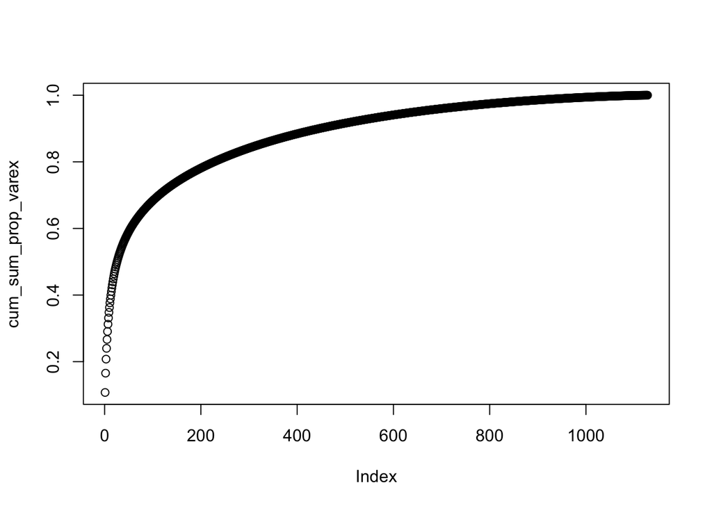

```r
mov_gen.pca <- prcomp(mov_gen_df, scale. = TRUE)

mov_gen.pca_var <- mov_gen.pca$sdev^2
prop_varex = mov_gen.pca_var/sum(mov_gen.pca_var)
cum_sum_prop_varex = cumsum(prop_varex)
plot(cum_sum_prop_varex, type = "b")
```

```r
cum_sum_prop_varex[440:500]
```

```
##  [1] 0.8979748 0.8983016 0.8986264 0.8989506 0.8992744 0.8995974 0.8999196
##  [8] 0.9002400 0.9005595 0.9008786 0.9011973 0.9015146 0.9018306 0.9021460
## [15] 0.9024606 0.9027739 0.9030870 0.9033999 0.9037120 0.9040226 0.9043328
## [22] 0.9046418 0.9049503 0.9052585 0.9055659 0.9058725 0.9061787 0.9064841
## [29] 0.9067886 0.9070924 0.9073957 0.9076977 0.9079986 0.9082990 0.9085980
## [36] 0.9088963 0.9091933 0.9094893 0.9097846 0.9100797 0.9103744 0.9106677
## [43] 0.9109606 0.9112519 0.9115421 0.9118320 0.9121207 0.9124088 0.9126964
## [50] 0.9129833 0.9132694 0.9135546 0.9138392 0.9141232 0.9144064 0.9146893
## [57] 0.9149717 0.9152531 0.9155334 0.9158127 0.9160917
```

We choose 447 PCs which explains 90.02% of the variability in the data.  
**Save the movieId and a number of PCs to capture 90% of the variability in a dataframe**

```r
mg_pca_df <- data.frame(mov_gen.pca$x[,1:447], row.names = rownames(mov_gen_df))
```

## Question 3

**Pick your favorite movie from 2015 or earlier and find it’s movieId in the Movies.csv file**  
My favorite movie is Harry Potter and the Sorcerer’s Stone with movieid: 4896.

**Compute the data frame of distances between your chosen movie and every other movie you have genome data for**

```r
dist_df <- data.frame(movieId = numeric(nrow(mg_pca_df)), dist = numeric(nrow(mg_pca_df)))

row_num = 1
for (movieId in rownames(mov_gen_df)){
  dist_df[row_num, "movieId"] <- movieId
  dist_df[row_num, 'dist'] <- dist(rbind(mg_pca_df["4896",],mg_pca_df[movieId,]), method = "euclidean")
  row_num = row_num + 1
}

write.csv(dist_df, "harry_potter_dist.csv")
mov_df[arrange(dist_df,dist)[2:4,1],1]
```

```
## [1] "Harry Potter and the Chamber of Secrets (2002)"
## [2] "Harry Potter and the Goblet of Fire (2005)"
## [3] "Harry Potter and the Prisoner of Azkaban (2004)"
```

```r
mov_df[arrange(dist_df,desc(dist))[1:3,1],1]
```

```
## [1] "American History X (1998)" "Memento (2000)"
## [3] "Matrix, The (1999)"
```

## Question 4

**Reduce the data in the ratings to only users who have rated your chosen movie**

```r
userId_list <- rating_df %>%
  filter(movieId == '4896')

userId_list <- as.list(userId_list[1:10000,'userId'])

rating_short_df <- rating_df %>%
  filter(userId %in% userId_list)
```

## Question 5

**Predict each user will rate the movie the global average of that movie’s ratings**

```r
mov_benchmark <- rating_short_df %>%
  group_by(movieId) %>%
  summarize(predicted_rating = mean(rating)) %>%
  filter(movieId == "4896")
```

**Predict each user will rate the movie the average of their own ratings for all movies**

```r
user_benchmark <- rating_short_df %>%
  group_by(userId) %>%
  summarize(predicted_rating = mean(rating))
```

## Question 6

**Write a k-nearest neighbors function**

```r
knn <- function(closest_mov, k) {
  return (mean(closest_mov[1:k,'rating']))
}
```

## Question 7

**Loop over all users who have seen your movie, and predict their rating for k = 1, … , 50 with your knn function**

```r
rating_short_df = merge(x = rating_short_df, y = dist_df, by = "movieId", all.x = TRUE)
rating_short_df <- arrange(rating_short_df, userId, dist)

user_split_df <- split(rating_short_df, rating_short_df$userId)

runKnn <- function(x) {
  knn_predicted <- numeric(length(userId_list))
  row_num = 1
  for (user in userId_list) {

    user_df <- user_split_df[[ row_num]]

    knn_predicted[row_num]= knn(user_df[2:nrow(user_df),], x)
    row_num = row_num + 1
  }
  return (knn_predicted)
}
start = Sys.time()
predicted_ratings <- lapply(1:50, runKnn)
end = Sys.time()
end - start
```

```
## Time difference of 18.10652 secs
```

```r
predicted_df <- data.frame(userId = unlist(userId_list),predicted_ratings)
colnames(predicted_df) <- c('userId',paste('k',1:50,sep = ""))
```

## Question 8

**Make a graph with the x-axis as k, the y-axis as MSE, and three lines**

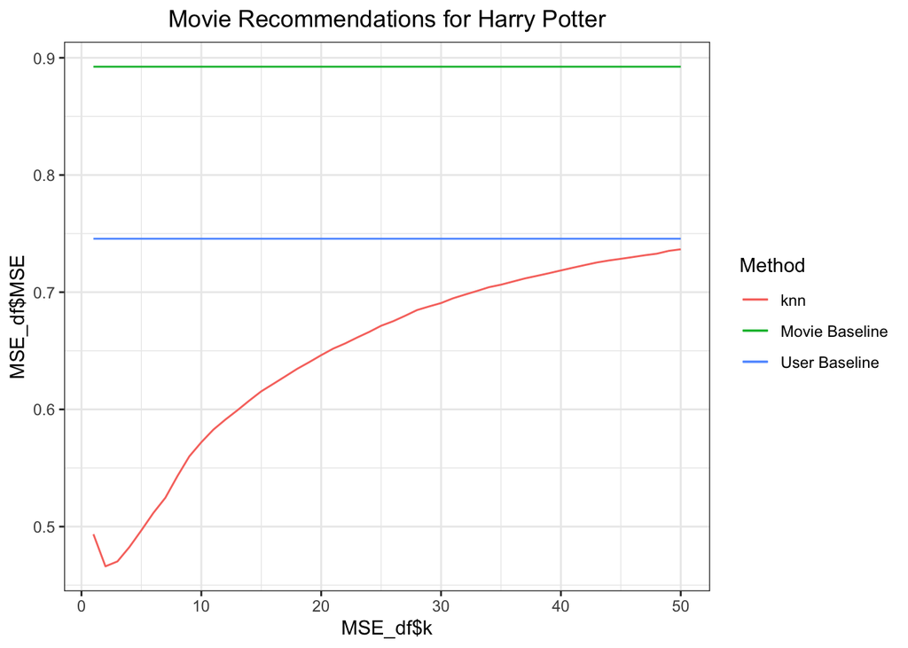

```r
actual_rating_df <- rating_short_df %>%
  filter(movieId == 4896)
predicted_df = merge(x = predicted_df, y = actual_rating_df, by = "userId", all.x = TRUE)

MSE <- lapply(paste('k',1:50,sep = ""), function (x) mean((predicted_df[,'rating']-predicted_df[,x])^2))
MSE_df <- data.frame(k = 1:50)
MSE_df$MSE <- unlist(MSE)
MSE_df$k <- as.numeric(MSE_df$k)

mov_MSE <- lapply(1:nrow(actual_rating_df), function(x) (actual_rating_df[x,"rating"]-mov_benchmark[1,2])^2)
mov_MSE <- mean(unlist(mov_MSE))

user_benchmark_df = merge(x = user_benchmark, y = actual_rating_df, by = "userId", all.x = TRUE)
user_MSE <- mean((user_benchmark_df[,'rating']-user_benchmark_df[,'predicted_rating'])^2)


ggplot() +
  geom_line(aes(MSE_df$k,MSE_df$MSE, color = "knn")) +
  geom_line(aes(MSE_df$k,mov_MSE, color = "Movie Baseline")) +
  geom_line(aes(MSE_df$k,user_MSE, color = "User Baseline")) +
  labs(title = "Movie Recommendations for Harry Potter",color = "Method") +
  theme_bw() +
  theme(plot.title = element_text(hjust = 0.5))
```

The best choice of parameter is k = 2 which has the smallest MSE (0.466). This means that for each user, the rating that they would most likely to give for the first movie of Harry Potter is the mean of the rating they give for the two closest movies. The reason why k is so small is that most users who watched the first movie of Harry Potter are users who watched the second, third movie or even all of the series. Therefore the two closest movies with the first movie of Harry Potter would be likely to be other movies in the Harry Potter series. Users who enjoyed the second, third, … movies would be likely to enjoy the first movie and vice versa. Therefore, the mean of two closest movies makes a great prediction. That’s why we only need a small value of k to predict the rating of the first movie of Harry Potter.  
My predictions are good as the MSEs using knn are always below the movie and user baseline. This may be because the distances between the k-nearest movies and my movie are small which means that my movie may be really similiar to the k-nearest movies. Therefore, if users rate the k-nearest movies high, they would also rate my movie high and hence minimize the MSE.  
In the context of the recommendation problem, high MSE means that we wrongly predict whether the user likes the movie or not, while low MSE means that we accurately predict whether the user likes the movie or not. High MSE, therefore, indicates a not very good recommendation system, while low MSE indicates a good recommendation.

## Question 9

**How would we use this output to make recommendations about which movies to suggest for this individual? What steps could we take to make this task computationally feasible?**  
With this output, we would recommend the first movie of Harry Potter to people who are predicted to have a high rating for it.  
To make this more computationally feasible:

- In this lab, we focus on one movie and predict to see if other people will like that movie and then recommend it to them. This takes a large training time as we also make predictions for those individuals that are likely to rate the movie low or even don’t care about this movie. This happens because we make predictions for all users. Instead, we should make predictions for only users that are likely to rate our movie high in order to justify that we should recommend our movie to them. After a user finished watching a movie, there are two cases: they rate the movie and they don’t rate the movie. If they rate the movie, we would only proceed with movie that are rated high. If they don’t rate it, we assume that they like it and proceed. With that movie, we find the nearest movie based on the Euclidean distance. With the user’s ratings for other movies, we predict the rating the user will give for the nearest movie. If it’s high then we recommend. If it’s low then we don’t recommend. We repeat the process until we could find enough movies to recommend.  
  This approach saves time as we only focus on movies that are close to the movies the user just watched or rated high. We eliminate all of the unnecessary predictions on movies that the users don’t even care. Also, we can stop predicting when we have enough movies to recommend.
- Another way to save the computational time when we have a movie and want to predict all other users’ ratings on our movie is to sort the data set based on userId and distance first. And then just cut the large data set into smaller ones for each user. With this approach, we don’t have to loop over the large data set to get the user, rating, and dist we want each time we predict on different users. My code can demonstrate this. Instead of 5 hours, it only took me a minute to train my model.